# Titanic

Tshegofatso Kgomo

2024-03-29

```r
###Loading Packages
library(haven)
library(ggplot2)
library(ggthemes)
library(dplyr)
library(apaTables)
library(corrgram)
library(corrplot)
library(DescTools)
library(caTools)
library(rpart)
library(rpart.plot)
library(GGally)
library(reshape2)
library(caret)
###Loading the Titanic data set
titanic <- read.csv("Titanic-Dataset.csv")
```

```r
###Overview of the Titanic data set
summary(titanic)
```

```
##   PassengerId       Survived          Pclass          Name
##  Min.   :  1.0   Min.   :0.0000   Min.   :1.000   Length:891
##  1st Qu.:223.5   1st Qu.:0.0000   1st Qu.:2.000   Class :character
##  Median :446.0   Median :0.0000   Median :3.000   Mode  :character
##  Mean   :446.0   Mean   :0.3838   Mean   :2.309
##  3rd Qu.:668.5   3rd Qu.:1.0000   3rd Qu.:3.000
##  Max.   :891.0   Max.   :1.0000   Max.   :3.000
##
##      Sex                 Age            SibSp           Parch
##  Length:891         Min.   : 0.42   Min.   :0.000   Min.   :0.0000
##  Class :character   1st Qu.:20.12   1st Qu.:0.000   1st Qu.:0.0000
##  Mode  :character   Median :28.00   Median :0.000   Median :0.0000
##                     Mean   :29.70   Mean   :0.523   Mean   :0.3816
##                     3rd Qu.:38.00   3rd Qu.:1.000   3rd Qu.:0.0000
##                     Max.   :80.00   Max.   :8.000   Max.   :6.0000
##                     NA's   :177
##     Ticket               Fare           Cabin             Embarked
##  Length:891         Min.   :  0.00   Length:891         Length:891
##  Class :character   1st Qu.:  7.91   Class :character   Class :character
##  Mode  :character   Median : 14.45   Mode  :character   Mode  :character
##                     Mean   : 32.20
##                     3rd Qu.: 31.00
##                     Max.   :512.33
##
```

```r
str(titanic)
```

```
## 'data.frame':    891 obs. of  12 variables:
##  $ PassengerId: int  1 2 3 4 5 6 7 8 9 10 ...
##  $ Survived   : int  0 1 1 1 0 0 0 0 1 1 ...
##  $ Pclass     : int  3 1 3 1 3 3 1 3 3 2 ...
##  $ Name       : chr  "Braund, Mr. Owen Harris" "Cumings, Mrs. John Bradley (Florence Briggs Thayer)" "Heikkinen, Miss. Laina" "Futrelle, Mrs. Jacques Heath (Lily May Peel)" ...
##  $ Sex        : chr  "male" "female" "female" "female" ...
##  $ Age        : num  22 38 26 35 35 NA 54 2 27 14 ...
##  $ SibSp      : int  1 1 0 1 0 0 0 3 0 1 ...
##  $ Parch      : int  0 0 0 0 0 0 0 1 2 0 ...
##  $ Ticket     : chr  "A/5 21171" "PC 17599" "STON/O2. 3101282" "113803" ...
##  $ Fare       : num  7.25 71.28 7.92 53.1 8.05 ...
##  $ Cabin      : chr  "" "C85" "" "C123" ...
##  $ Embarked   : chr  "S" "C" "S" "S" ...
```

```r
head(titanic)
```

```
##   PassengerId Survived Pclass
## 1           1        0      3
## 2           2        1      1
## 3           3        1      3
## 4           4        1      1
## 5           5        0      3
## 6           6        0      3
##                                                  Name    Sex Age SibSp Parch
## 1                             Braund, Mr. Owen Harris   male  22     1     0
## 2 Cumings, Mrs. John Bradley (Florence Briggs Thayer) female  38     1     0
## 3                              Heikkinen, Miss. Laina female  26     0     0
## 4        Futrelle, Mrs. Jacques Heath (Lily May Peel) female  35     1     0
## 5                            Allen, Mr. William Henry   male  35     0     0
## 6                                    Moran, Mr. James   male  NA     0     0
##             Ticket    Fare Cabin Embarked
## 1        A/5 21171  7.2500              S
## 2         PC 17599 71.2833   C85        C
## 3 STON/O2. 3101282  7.9250              S
## 4           113803 53.1000  C123        S
## 5           373450  8.0500              S
## 6           330877  8.4583              Q
```

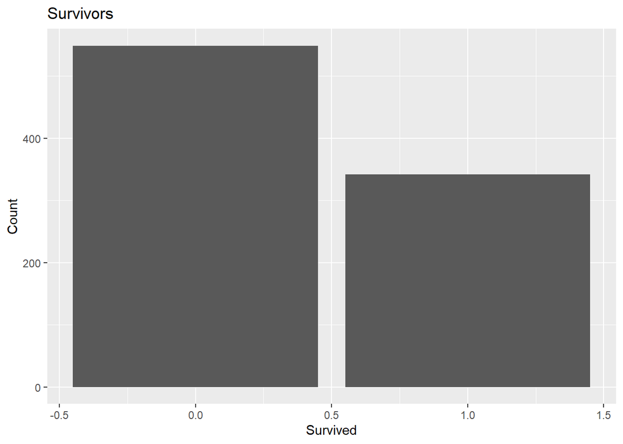

```r
###Frequency Count
ggplot(titanic, aes(x= Survived))+
  geom_bar()+
  labs(title = "Survivors", X = "Survivors", y= "Count")
```

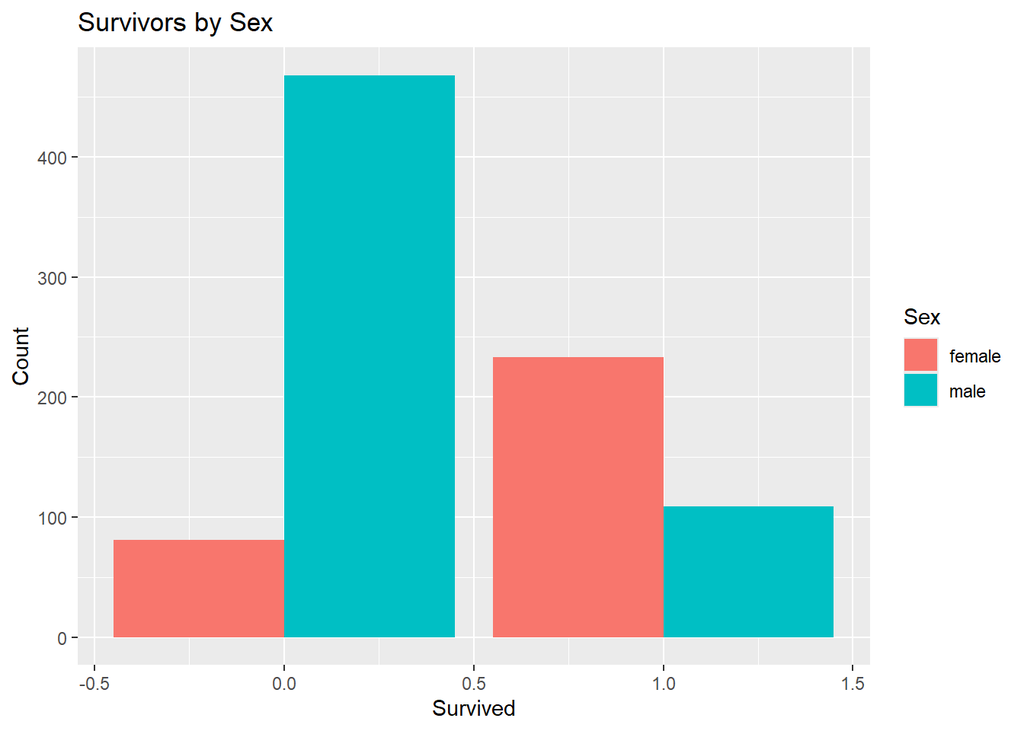

```r
ggplot(titanic, aes(x= Survived, fill= Sex))+
  geom_bar(position = "dodge")+
  labs(x= "Survived", y= "Count", fill= "Sex")+
  ggtitle("Survivors by Sex")
```

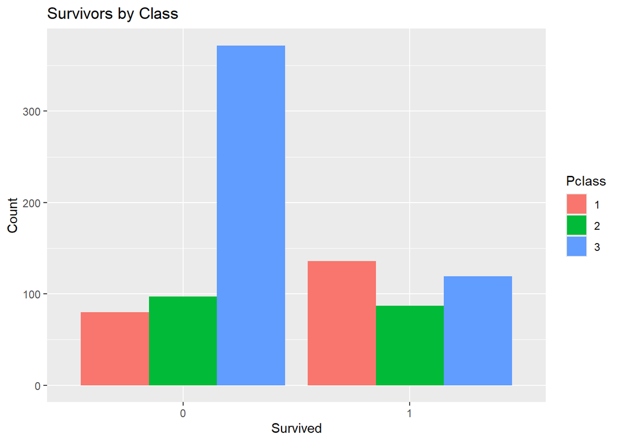

```r
ggplot(titanic, aes(x= factor(Survived), fill= factor(Pclass)))+
  geom_bar(position = "dodge")+
  labs(x= "Survived", y= "Count", fill= "Pclass")+
  ggtitle("Survivors by Class")
```

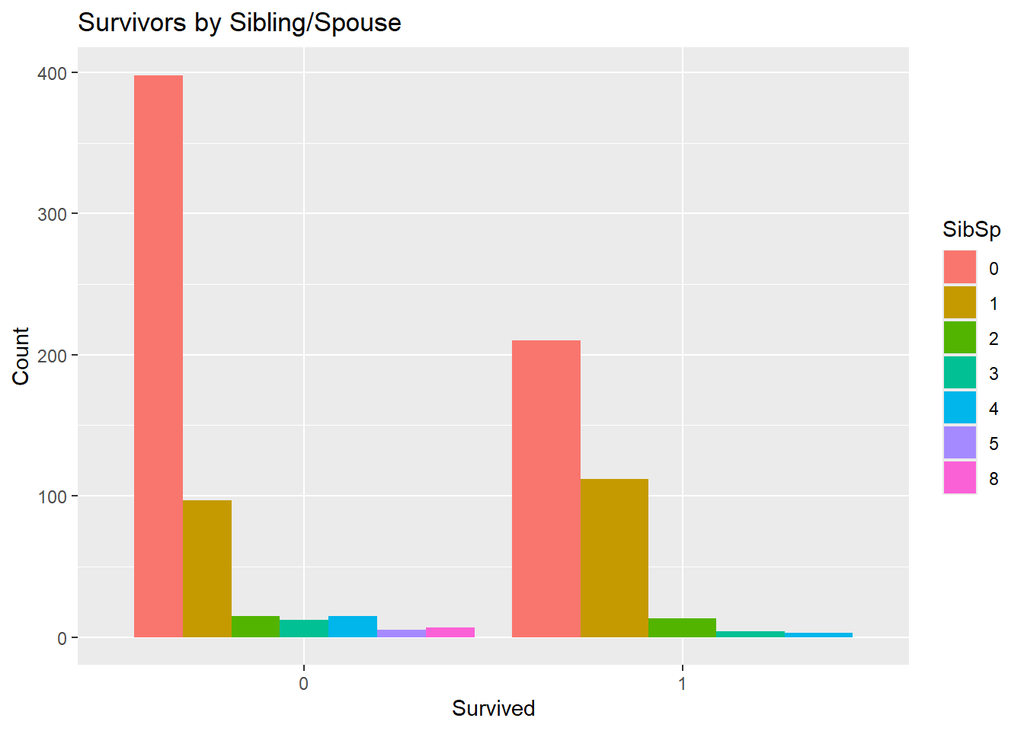

```r
ggplot(titanic, aes(x= factor(Survived), fill= factor(SibSp)))+
  geom_bar(position = "dodge")+
  labs(x= "Survived", y= "Count", fill= "SibSp")+
  ggtitle("Survivors by Sibling/Spouse")
```

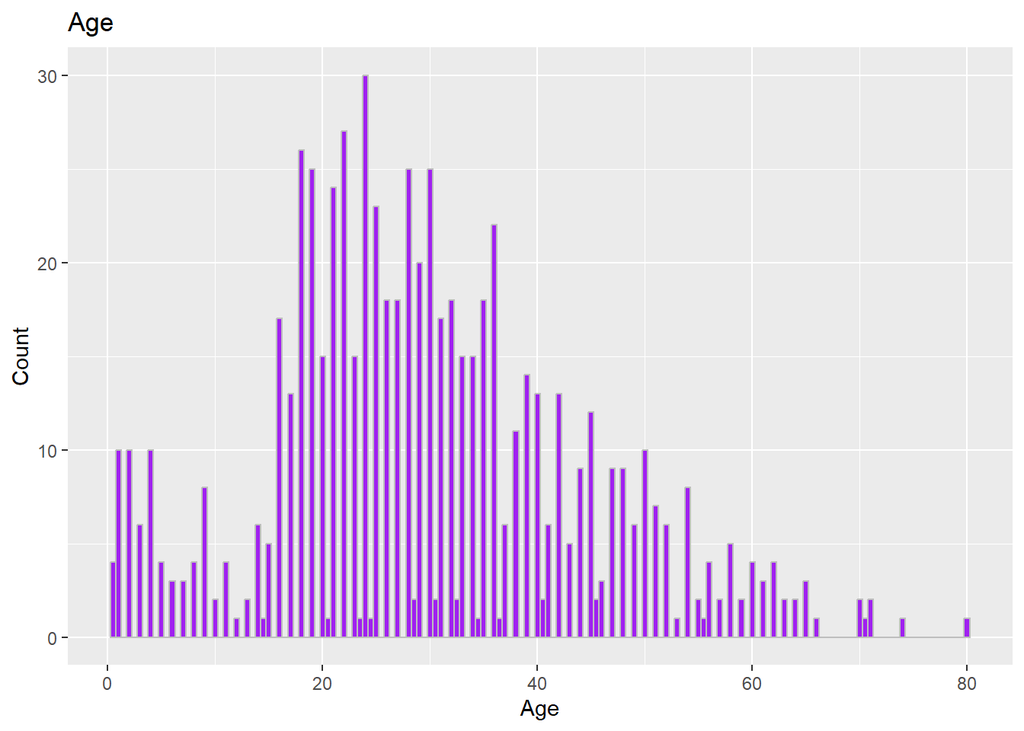

```r
ggplot(titanic, aes(x= Age))+
  geom_histogram(binwidth = 0.5, fill = "purple", color ="grey")+
  labs(title = "Age", X = "Age", y= "Count")
```

*More people did not survive.*

*More male travellers did not survive.*

*Most of the travellers who did not survive were in 3rd class.*

*Most of the travellers had either no siblings or 1 sibling.*

*Most of the travellers were between 18-36, and the oldest traveller being 80 years*

```r
###checking for missing values
titanic[titanic$Name=="", ]
```

```
##  [1] PassengerId Survived    Pclass      Name        Sex         Age
##  [7] SibSp       Parch       Ticket      Fare        Cabin       Embarked
## <0 rows> (or 0-length row.names)
```

```r
titanic[titanic$Sex=="", ]
```

```
##  [1] PassengerId Survived    Pclass      Name        Sex         Age
##  [7] SibSp       Parch       Ticket      Fare        Cabin       Embarked
## <0 rows> (or 0-length row.names)
```

```r
titanic[titanic$Cabin=="", ]
```

[output not shown]

[output cut: 2049 more lines]

```r
sum(is.na(titanic$Age))
```

```
## [1] 177
```

The Cabin Variable has 687 missing values, and the Age variable has 177 missing values.

```r
###Data for analysis
titanic2 <- titanic[, c(2,3,5,6,7,8)]
```

To decision is to drop PassengerID, Name, Ticket, Fare, Cabin, and Embarked. These are dropped because they will provide much information in this instance of the analysis.

```r
###Replacing Missing Values
sum(is.na(titanic2$Age))
```

```
## [1] 177
```

```r
md <- Mode(titanic2$Age, na.rm = TRUE)
md
```

```
## [1] 24
## attr(,"freq")
## [1] 30
```

```r
titanic2$Age <- ifelse(is.na(titanic2$Age), md, titanic2$Age)
sum(is.na(titanic2$Age))
```

```
## [1] 0
```

The missing values in the Age variable are replaced with the mode of the Age variable.

```r
###Summary statistics
head(titanic2)
```

```
##   Survived Pclass    Sex Age SibSp Parch
## 1        0      3   male  22     1     0
## 2        1      1 female  38     1     0
## 3        1      3 female  26     0     0
## 4        1      1 female  35     1     0
## 5        0      3   male  35     0     0
## 6        0      3   male  24     0     0
```

```r
summary(titanic2)
```

```
##     Survived          Pclass          Sex                 Age
##  Min.   :0.0000   Min.   :1.000   Length:891         Min.   : 0.42
##  1st Qu.:0.0000   1st Qu.:2.000   Class :character   1st Qu.:22.00
##  Median :0.0000   Median :3.000   Mode  :character   Median :24.00
##  Mean   :0.3838   Mean   :2.309                      Mean   :28.57
##  3rd Qu.:1.0000   3rd Qu.:3.000                      3rd Qu.:35.00
##  Max.   :1.0000   Max.   :3.000                      Max.   :80.00
##      SibSp           Parch
##  Min.   :0.000   Min.   :0.0000
##  1st Qu.:0.000   1st Qu.:0.0000
##  Median :0.000   Median :0.0000
##  Mean   :0.523   Mean   :0.3816
##  3rd Qu.:1.000   3rd Qu.:0.0000
##  Max.   :8.000   Max.   :6.0000
```

```r
str(titanic2)
```

```
## 'data.frame':    891 obs. of  6 variables:
##  $ Survived: int  0 1 1 1 0 0 0 0 1 1 ...
##  $ Pclass  : int  3 1 3 1 3 3 1 3 3 2 ...
##  $ Sex     : chr  "male" "female" "female" "female" ...
##  $ Age     : num  22 38 26 35 35 24 54 2 27 14 ...
##  $ SibSp   : int  1 1 0 1 0 0 0 3 0 1 ...
##  $ Parch   : int  0 0 0 0 0 0 0 1 2 0 ...
```

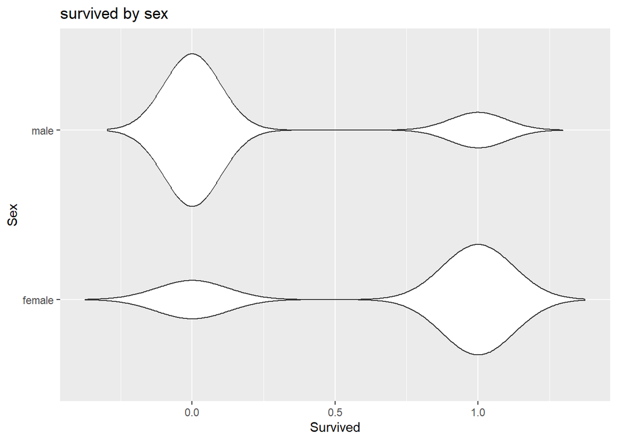

```r
### Using various visuals to see the final data set for analysis
ggplot(titanic2, aes(Survived, Sex))+
  geom_violin(trim = FALSE)+
  ggtitle("survived by sex")
```

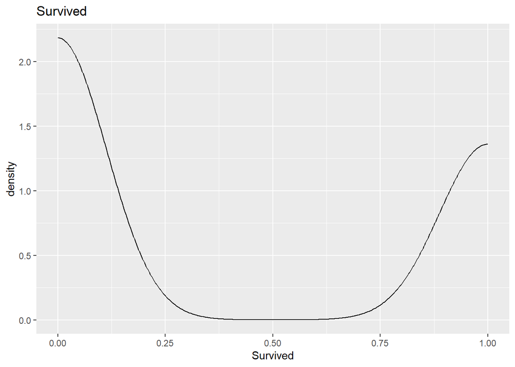

```r
ggplot(titanic2, aes(Survived)) + geom_density()+ ggtitle("Survived")
```

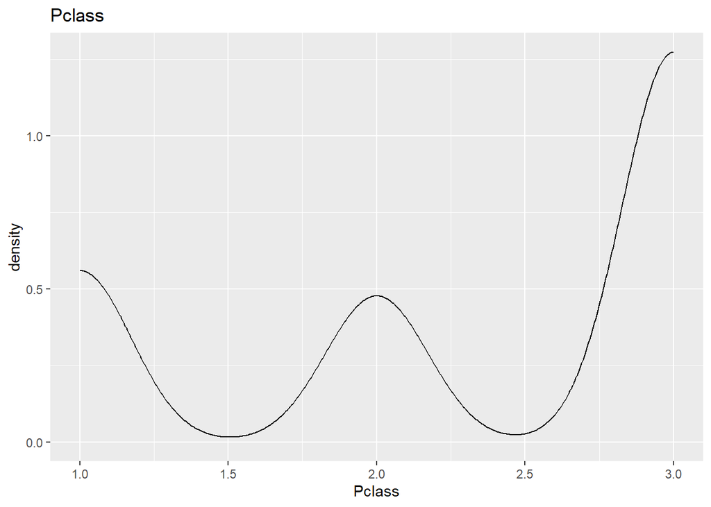

```r
ggplot(titanic2, aes(Pclass)) + geom_density()+ ggtitle("Pclass")
```

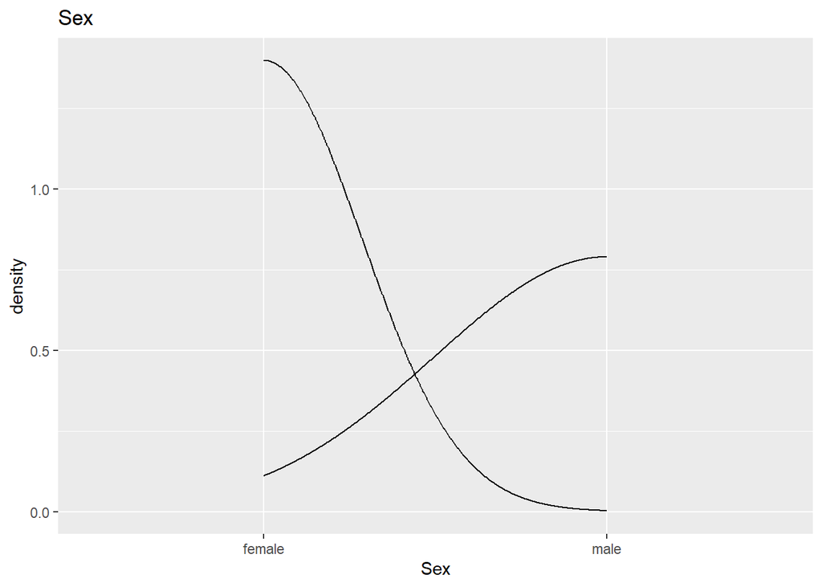

```r
ggplot(titanic2, aes(Sex)) + geom_density()+ ggtitle("Sex")
```

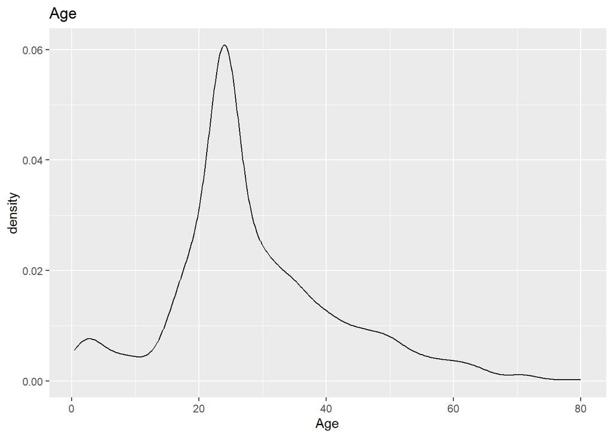

```r
ggplot(titanic2, aes(Age)) + geom_density()+ ggtitle("Age")
```

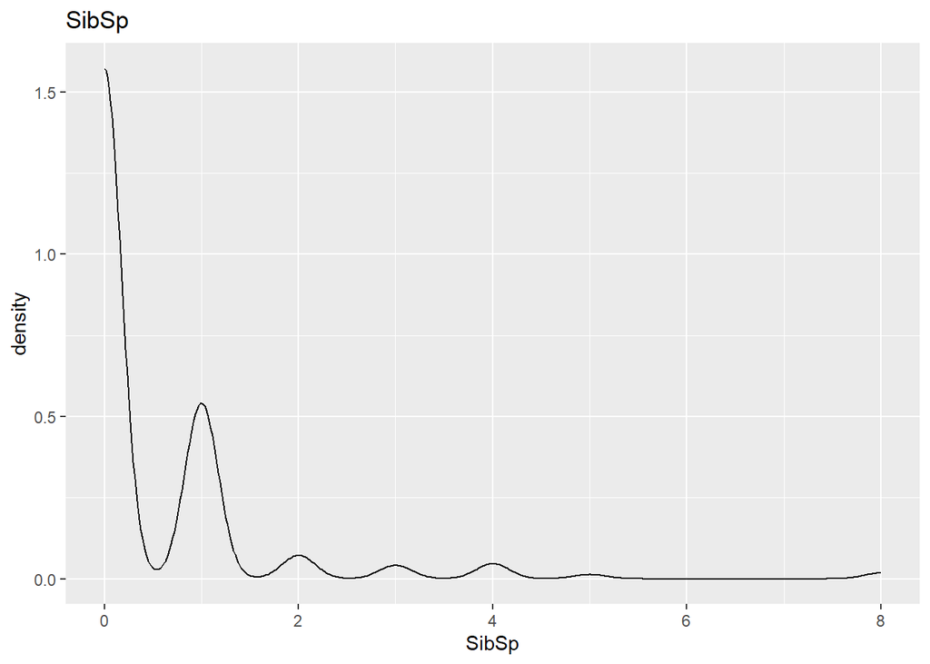

```r
ggplot(titanic2, aes(SibSp)) + geom_density()+ ggtitle("SibSp")
```

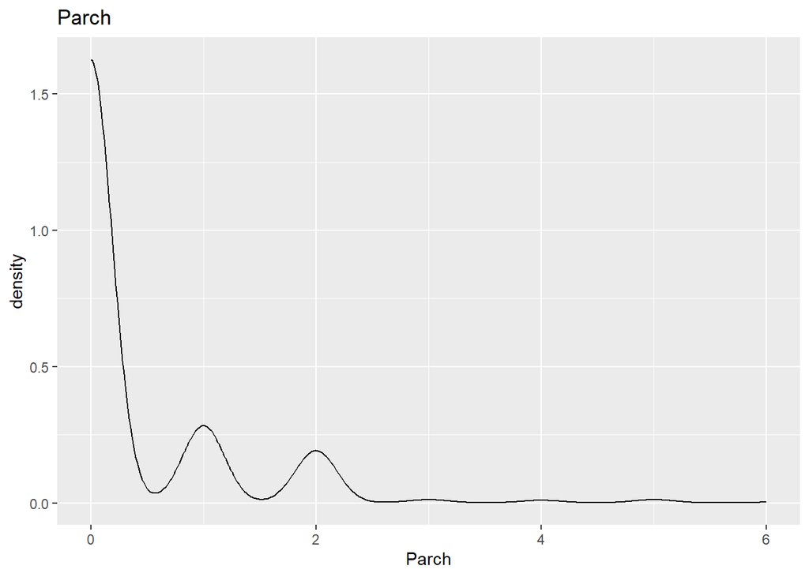

```r
ggplot(titanic2, aes(Parch)) + geom_density()+ ggtitle("Parch")
```

```r
data.long <- melt(titanic2)
```

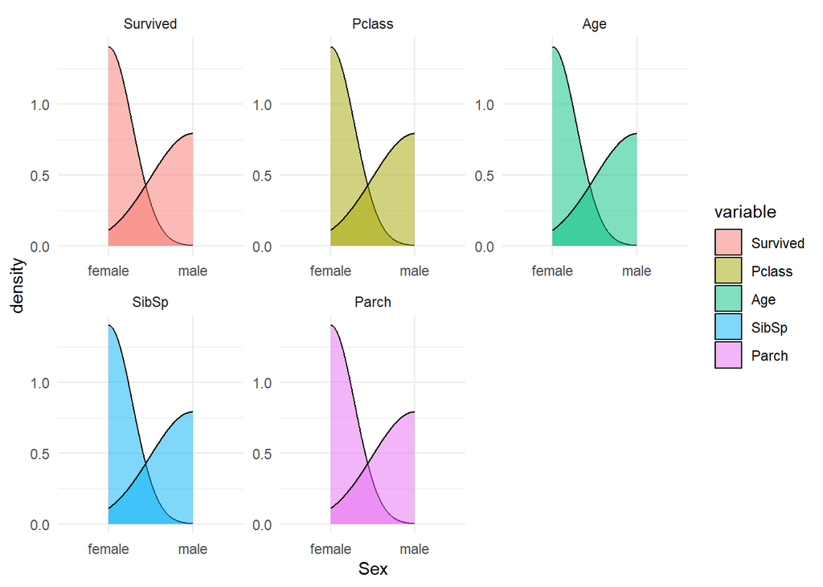

```r
ggplot(data.long, aes(Sex, fill= variable))+
  geom_density(alpha=0.5)+
  facet_wrap(~variable, scales = "free")+
  theme_minimal()
```

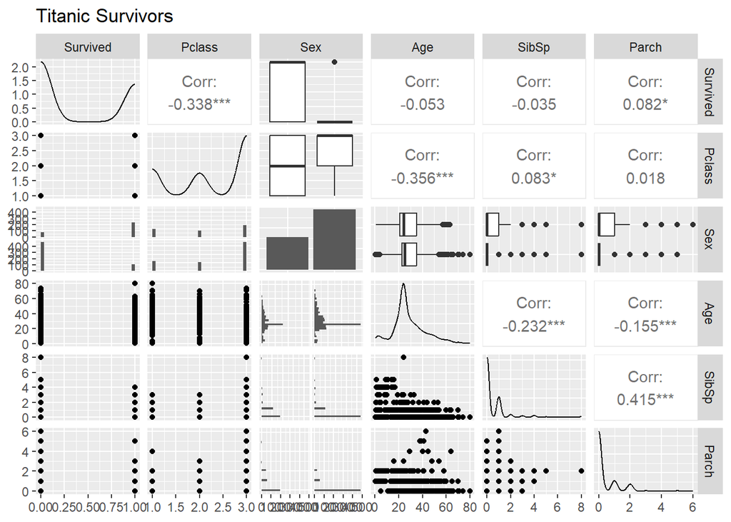

```r
###Correlation between the variables
ggpairs(data = titanic2, columns= c(1,2, 3,4,5,6), title = "Titanic Survivors")
```

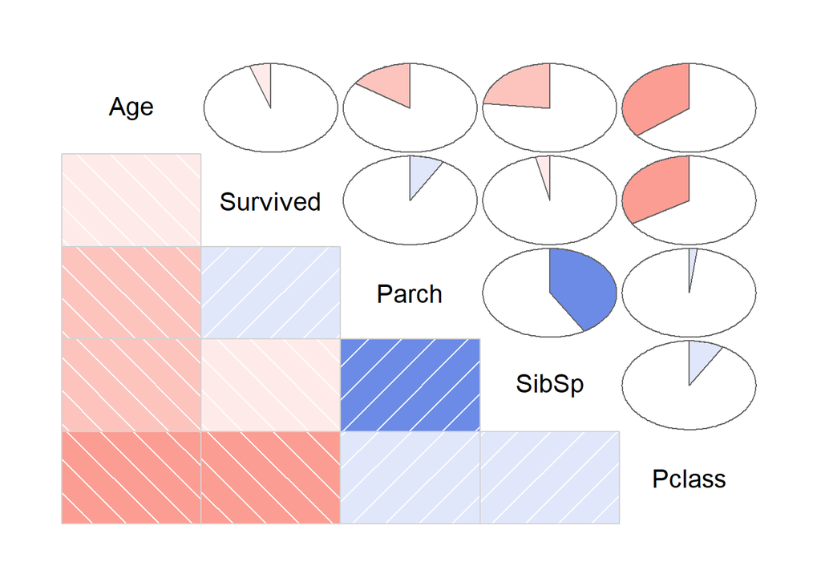

```r
corrgram(titanic2, order = TRUE, lower.panel = panel.shade, upper.panel = panel.pie)
```

```r
###changing survived variable into factor
new.labels <- c("Died", "Survived")
titanic2$Survived <- factor(titanic2$Survived, labels = new.labels)
table(titanic2$Survived)
```

```
##
##     Died Survived
##      549      342
```

```r
titanic2$Sex <- factor(titanic2$Sex)
```

```r
###training data
set.seed(101)
sample <- sample.split(titanic2$Survived, SplitRatio = 0.5)

train <- subset(titanic2, sample == TRUE)
test <- subset(titanic2, sample == FALSE)
```

The data is split into training and test data.

```r
traindata <- train[,2:6]
trainclass <- train[,1]
tr <- trainControl(method = "cv", number = 5, savePredictions = TRUE)
titanicPredict <- train(traindata, trainclass,
              method = "rpart",
              trControl = tr)

confusionMatrix(titanicPredict)
```

```
## Cross-Validated (5 fold) Confusion Matrix
##
## (entries are percentual average cell counts across resamples)
##
##           Reference
## Prediction Died Survived
##   Died     55.3     14.8
##   Survived  6.3     23.6
##
##  Accuracy (average) : 0.7888
```

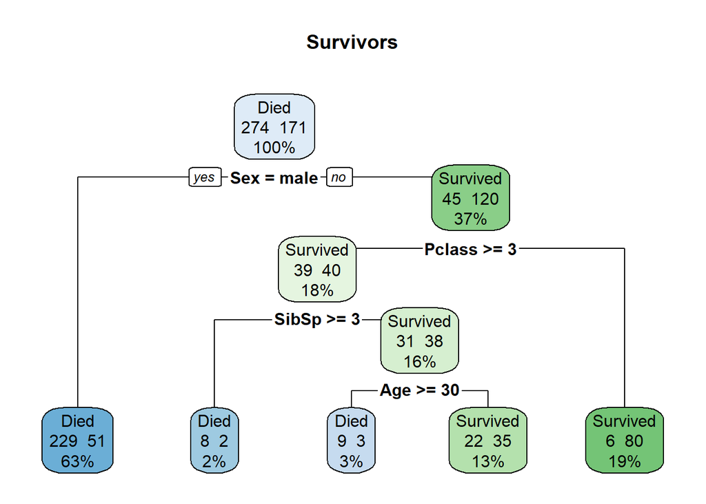

```r
rpart.plot(titanicPredict$finalModel, box.palette = "BuGn",main = "Survivors", extra = 101)
```

```r
rpart.rules(titanicPredict$finalModel, cover = TRUE, clip.facs = TRUE)
```

```
##  .outcome                                                      cover
##      0.18 when   male                                            63%
##      0.20 when female & Pclass >= 3 & SibSp >= 3                  2%
##      0.25 when female & Pclass >= 3 & SibSp <  3 & Age >= 30      3%
##      0.61 when female & Pclass >= 3 & SibSp <  3 & Age <  30     13%
##      0.93 when female & Pclass <  3                              19%
```

```r
TestPredict <- rpart.predict(titanicPredict,test)

table(TestPredict, test$Survived) %>%
  prop.table()%>%
  round(3)
```

```
##
## TestPredict  Died Survived
##    Died     0.572    0.141
##    Survived 0.045    0.242
```

## Confusion Matrix

The confusion matrix has an accuracy average of 78.8%.

## Decision Tree Model

More male travellers did not survive the titanic crash.

Of those who did not survive, majority were from 3rd class.

## Predicition

The prediction of the model are not far off, when testing data is used.